# R_Project_6607_f23

Yagghaseni Saha Roy, 202286106

Date: 2023-12-13

# Dataset Description

The dataset “boneExam.csv” originates from the Third National Health and Nutrition Examination Survey (NHANES III) conducted between 1988 and 1994 in the United States. NHANES III is a comprehensive survey by the National Center for Health Statistics (NCHS) aimed at assessing the health and nutritional status of a representative U.S. population. Comprising 31,311 observations across 35 variables, the dataset provides a detailed snapshot of individuals’ demographics, anthropometric measurements, and health-related information. Variables such as SEQN (participant identifier), DMARETHN (ethnicity), and HSSEX (gender) are included. This dataset serves as a crucial resource for researchers and policymakers, offering insights into health trends, risk factors, and relationships between various demographic factors and health outcomes.

# Variable Types and Statistical Measures

1. Categorical Variables: Examples: DMARETHN (Ethnicity), DMARACER (Race), DMAETHNR (Ethnicity and race recode), HSSEX (Gender), PEPPREG (Pregnancy status) Statistical Measures: Frequency tables and bar charts to show distribution.
2. Numerical Variables: Examples: BMPWT (Weight), BMPBMI (Body Mass Index), BMPHT (Height), BMPARMC (Arm circumference) Statistical Measures: Histograms and boxplots to visualize the distribution.
3. Binary Variables: Examples: DRPNKCAL (Indicator for daily calorie intake) Statistical Measures: Proportions or percentages to describe the distribution.
4. Continuous Variables: Examples: BMPWHR (Waist-Hip Ratio), BMPTHICI (Hip circumference), BDPFNBMD (Bone density of the femoral neck) Statistical Measures: Scatter plots for relationships with other variables.

# Claim

In this project, I will explore if there are any correlation between BMI and bone health, age and bone health. And if ethnicty and gender make any difference in bone density.

```r
bone_exam <- read.csv("boneExam.csv")

print("Column Information:")
```

```
## [1] "Column Information:"
```

```r
str(bone_exam)
```

```
## 'data.frame':    31311 obs. of  35 variables:
##  $ SEQN    : int  3 4 7 9 10 11 12 13 14 16 ...
##  $ DMARETHN: int  3 3 2 1 1 3 1 1 1 3 ...
##  $ DMARACER: int  1 1 2 1 1 1 1 1 1 1 ...
##  $ DMAETHNR: int  1 1 3 3 3 1 3 3 3 1 ...
##  $ HSSEX   : int  1 2 2 2 1 1 2 1 2 1 ...
##  $ HSAGEIR : int  21 32 3 48 35 48 2 1 16 16 ...
##  $ BMPWT   : num  81.6 61.6 13.1 68 92.5 ...
##  $ BMPBMI  : num  25.5 23.4 13.8 27.6 29.4 25 NA NA 17.1 22.3 ...
##  $ BMPHT   : num  178.8 162.2 97.3 156.9 177.4 ...
##  $ BMPARMC : num  34.9 32.8 15.6 33.3 36.1 31.2 14.6 17.2 21.9 29.6 ...
##  $ BMPWAIST: num  88.8 90.5 43.3 89.5 102.2 ...
##  $ BMPBUTTO: num  97.7 98.9 49.4 106.3 105.9 ...
##  $ BMPWHR  : num  0.91 0.92 0.88 0.84 0.97 1 NA NA 0.73 0.88 ...
##  $ BMPTHICI: num  53.5 46.9 26.1 51.1 57 46.5 NA NA 43.8 48.3 ...
```

[output cut: 21 more lines]

## Summary of dataset

```r
library(dplyr)
bone_data <- read.csv("boneExam.csv", na.strings = c("NA", "NaN"))
missing_values <- sapply(bone_data, function(x) sum(is.na(x)))
print(missing_values[missing_values > 0])
```

```
##   BMPBMI    BMPHT BMPWAIST BMPBUTTO   BMPWHR BMPTHICI  PEPPREG DRPNKCAL
##     3254     3254     3712     3712     3712     3712    11527    31311
##    MYPB1    MYPB2    MYPB3    MYPB4    MYPB5   MYPB6R   MYPB7R    MYPB8
##    27030    30424    30424    31028    31028    31056    31056    31056
##   MYPB9S   MYPB10   MYPB11   MYPB12  MYPB13S   MYPB14   MYPC17 BDPFNBMD
##    31114    31056    30452    31283    31283    31283    31202    14895
## BDPTRBMD BDPINBMD BDPTOBMD
##    14895    14895    14895
```

```r
summary(bone_data)
```

```
##       SEQN          DMARETHN        DMARACER        DMAETHNR
##  Min.   :    3   Min.   :1.000   Min.   :1.000   Min.   :1.000
##  1st Qu.:10924   1st Qu.:1.000   1st Qu.:1.000   1st Qu.:1.000
##  Median :21908   Median :2.000   Median :1.000   Median :3.000
##  Mean   :26757   Mean   :2.012   Mean   :1.374   Mean   :2.387
##  3rd Qu.:42699   3rd Qu.:3.000   3rd Qu.:2.000   3rd Qu.:3.000
##  Max.   :53623   Max.   :4.000   Max.   :8.000   Max.   :3.000
##
##      HSSEX          HSAGEIR          BMPWT              BMPBMI
##  Min.   :1.000   Min.   : 1.00   Min.   :     2.8   Min.   :   7.30
##  1st Qu.:1.000   1st Qu.: 7.00   1st Qu.:    22.2   1st Qu.:  18.30
##  Median :2.000   Median :23.00   Median :    59.5   Median :  23.40
##  Mean   :1.521   Mean   :29.95   Mean   :  5135.4   Mean   :  95.52
##  3rd Qu.:2.000   3rd Qu.:48.00   3rd Qu.:    76.3   3rd Qu.:  28.00
##  Max.   :2.000   Max.   :90.00   Max.   :888888.0   Max.   :8888.00
##                                                     NA's   :3254
##      BMPHT            BMPARMC          BMPWAIST          BMPBUTTO
##  Min.   :   73.6   Min.   :   9.0   Min.   :   34.5   Min.   :   27.8
##  1st Qu.:  142.7   1st Qu.:  18.8   1st Qu.:   65.0   1st Qu.:   77.7
##  Median :  160.5   Median :  28.0   Median :   83.5   Median :   94.4
##  Mean   :  537.8   Mean   : 391.9   Mean   : 4299.2   Mean   : 4300.6
##  3rd Qu.:  170.0   3rd Qu.:  33.0   3rd Qu.:   98.5   3rd Qu.:  103.9
##  Max.   :88888.0   Max.   :8888.0   Max.   :88888.0   Max.   :88888.0
##  NA's   :3254                       NA's   :3712      NA's   :3712
##      BMPWHR           BMPTHICI          PEPPREG      DRPNKCAL
##  Min.   :   0.51   Min.   :   16.0   Min.   :1.000   Mode:logical
##  1st Qu.:   0.85   1st Qu.:   40.3   1st Qu.:2.000   NA's:31311
##  Median :   0.91   Median :   48.1   Median :2.000
##  Mean   : 439.80   Mean   : 4588.2   Mean   :2.524
##  3rd Qu.:   0.98   3rd Qu.:   53.8   3rd Qu.:2.000
##  Max.   :8888.00   Max.   :88888.0   Max.   :9.000
##  NA's   :3712      NA's   :3712      NA's   :11527
##      MYPB1           MYPB2           MYPB3           MYPB4
##  Min.   :1.00    Min.   : 2.00   Min.   :1.000   Min.   : 0.0
##  1st Qu.:2.00    1st Qu.:10.00   1st Qu.:2.000   1st Qu.:14.0
##  Median :2.00    Median :13.00   Median :2.000   Median :88.0
##  Mean   :2.06    Mean   :25.74   Mean   :2.968   Mean   :55.8
##  3rd Qu.:2.00    3rd Qu.:15.00   3rd Qu.:2.000   3rd Qu.:88.0
##  Max.   :9.00    Max.   :99.00   Max.   :9.000   Max.   :88.0
##  NA's   :27030   NA's   :30424   NA's   :30424   NA's   :31028
```

[output cut: 17 more lines]

```
##  Min.   :  1.00   Min.   :1.000   Min.   :1.000   Min.   :    0.23
##  1st Qu.:  4.00   1st Qu.:2.000   1st Qu.:2.000   1st Qu.:    0.73
##  Median : 10.00   Median :2.000   Median :2.000   Median :    0.85
##  Mean   : 95.14   Mean   :1.857   Mean   :4.495   Mean   : 9584.79
##  3rd Qu.: 20.00   3rd Qu.:2.000   3rd Qu.:8.000   3rd Qu.:    1.00
##  Max.   :777.00   Max.   :2.000   Max.   :8.000   Max.   :88888.00
##  NA's   :31283    NA's   :31283   NA's   :31202   NA's   :14895
##     BDPTRBMD           BDPINBMD           BDPTOBMD
##  Min.   :    0.16   Min.   :    0.33   Min.   :    0.27
##  1st Qu.:    0.63   1st Qu.:    1.00   1st Qu.:    0.85
##  Median :    0.72   Median :    1.15   Median :    0.98
##  Mean   : 9584.68   Mean   : 9585.05   Mean   : 9584.90
##  3rd Qu.:    0.84   3rd Qu.:    1.32   3rd Qu.:    1.12
##  Max.   :88888.00   Max.   :88888.00   Max.   :88888.00
##  NA's   :14895      NA's   :14895      NA's   :14895
```

## Data Cleaning

Data cleaning is a crucial step in the data preparation process that involves identifying and correcting errors or inconsistencies in a dataset. This process ensures that the data is accurate, complete, and ready for analysis. Common data cleaning tasks include handling missing values, removing duplicates, correcting data types, and eliminating irrelevant or redundant information. The goal is to enhance the quality of the dataset, mitigate potential biases or inaccuracies, and create a more reliable foundation for meaningful analysis and interpretation.

```r
library(tidyverse)
library(dplyr)

df1 <- read.csv("boneExam.csv", na.strings = c("NA", "N/A", ""))

columns_to_remove <- c("DRPNKCAL", "MYPB1", "MYPB2", "MYPB3", "MYPB4", "MYPB5",
                        "MYPB6R", "MYPB7R", "MYPB8", "MYPB9S", "MYPB10", "MYPB11",
                        "MYPB12", "MYPB13S", "MYPB14", "MYPC17")

df <- select(df1, -one_of(columns_to_remove))

write.csv(df, "boneExam_removed.csv", row.names = FALSE)

str(df)
```

```
## 'data.frame':    31311 obs. of  19 variables:
##  $ SEQN    : int  3 4 7 9 10 11 12 13 14 16 ...
##  $ DMARETHN: int  3 3 2 1 1 3 1 1 1 3 ...
##  $ DMARACER: int  1 1 2 1 1 1 1 1 1 1 ...
##  $ DMAETHNR: int  1 1 3 3 3 1 3 3 3 1 ...
##  $ HSSEX   : int  1 2 2 2 1 1 2 1 2 1 ...
##  $ HSAGEIR : int  21 32 3 48 35 48 2 1 16 16 ...
##  $ BMPWT   : num  81.6 61.6 13.1 68 92.5 ...
##  $ BMPBMI  : num  25.5 23.4 13.8 27.6 29.4 25 NA NA 17.1 22.3 ...
##  $ BMPHT   : num  178.8 162.2 97.3 156.9 177.4 ...
##  $ BMPARMC : num  34.9 32.8 15.6 33.3 36.1 31.2 14.6 17.2 21.9 29.6 ...
##  $ BMPWAIST: num  88.8 90.5 43.3 89.5 102.2 ...
##  $ BMPBUTTO: num  97.7 98.9 49.4 106.3 105.9 ...
##  $ BMPWHR  : num  0.91 0.92 0.88 0.84 0.97 1 NA NA 0.73 0.88 ...
##  $ BMPTHICI: num  53.5 46.9 26.1 51.1 57 46.5 NA NA 43.8 48.3 ...
##  $ PEPPREG : int  2 2 NA 2 2 2 NA NA 2 2 ...
##  $ BDPFNBMD: num  9.87e-01 6.30e-01 NA 7.14e-01 8.89e+04 ...
##  $ BDPTRBMD: num  6.84e-01 4.62e-01 NA 8.17e-01 8.89e+04 ...
##  $ BDPINBMD: num  1.2 0.77 NA 1.22 88888 ...
##  $ BDPTOBMD: num  1.04 6.64e-01 NA 1.02 8.89e+04 ...
```

```r
df2 <- read.csv("boneExam_removed.csv", na.strings = c("NA", "N/A", ""))

df_cleaned2 <- df2 %>% na.omit()

write.csv(df_cleaned2, "boneExam_cleaned2.csv", row.names = FALSE)
```

## Summary of cleaned dataset

```r
library(dplyr)

cleaned_data <- read.csv("boneExam_cleaned2.csv", na.strings = c("NA", "NaN"))

summary(cleaned_data)
```

```
##       SEQN          DMARETHN       DMARACER        DMAETHNR         HSSEX
##  Min.   :    3   Min.   :1.00   Min.   :1.000   Min.   :1.000   Min.   :1.000
##  1st Qu.:11194   1st Qu.:1.00   1st Qu.:1.000   1st Qu.:1.000   1st Qu.:1.000
##  Median :32355   Median :2.00   Median :1.000   Median :3.000   Median :2.000
##  Mean   :27079   Mean   :1.94   Mean   :1.357   Mean   :2.435   Mean   :1.528
##  3rd Qu.:42882   3rd Qu.:3.00   3rd Qu.:2.000   3rd Qu.:3.000   3rd Qu.:2.000
##  Max.   :53616   Max.   :4.00   Max.   :8.000   Max.   :3.000   Max.   :2.000
##     HSAGEIR         BMPWT              BMPBMI            BMPHT
##  Min.   :20.0   Min.   :    31.2   Min.   :  11.70   Min.   :  126.9
##  1st Qu.:31.0   1st Qu.:    62.8   1st Qu.:  23.10   1st Qu.:  159.1
##  Median :44.0   Median :    73.3   Median :  26.30   Median :  166.2
##  Mean   :48.1   Mean   :  2620.0   Mean   :  53.57   Mean   :  323.1
##  3rd Qu.:64.0   3rd Qu.:    85.0   3rd Qu.:  30.10   3rd Qu.:  173.4
##  Max.   :90.0   Max.   :888888.0   Max.   :8888.00   Max.   :88888.0
##     BMPARMC          BMPWAIST          BMPBUTTO           BMPWHR
##  Min.   :  17.4   Min.   :   57.5   Min.   :   68.5   Min.   :   0.51
##  1st Qu.:  29.0   1st Qu.:   83.5   1st Qu.:   93.8   1st Qu.:   0.86
##  Median :  32.0   Median :   93.7   Median :  100.0   Median :   0.93
##  Mean   : 432.8   Mean   : 4615.3   Mean   : 4584.9   Mean   : 465.95
##  3rd Qu.:  35.4   3rd Qu.:  104.2   3rd Qu.:  108.3   3rd Qu.:   1.00
##  Max.   :8888.0   Max.   :88888.0   Max.   :88888.0   Max.   :8888.00
##     BMPTHICI        PEPPREG         BDPFNBMD           BDPTRBMD
##  Min.   :   26   Min.   :1.000   Min.   :    0.23   Min.   :    0.16
##  1st Qu.:   47   1st Qu.:2.000   1st Qu.:    0.73   1st Qu.:    0.63
##  Median :   51   Median :2.000   Median :    0.85   Median :    0.72
##  Mean   : 5003   Mean   :2.502   Mean   : 9584.79   Mean   : 9584.68
##  3rd Qu.:   56   3rd Qu.:2.000   3rd Qu.:    1.00   3rd Qu.:    0.84
##  Max.   :88888   Max.   :9.000   Max.   :88888.00   Max.   :88888.00
##     BDPINBMD           BDPTOBMD
##  Min.   :    0.33   Min.   :    0.27
##  1st Qu.:    1.00   1st Qu.:    0.85
##  Median :    1.15   Median :    0.98
##  Mean   : 9585.05   Mean   : 9584.90
##  3rd Qu.:    1.32   3rd Qu.:    1.12
##  Max.   :88888.00   Max.   :88888.00
```

## Graphical Display

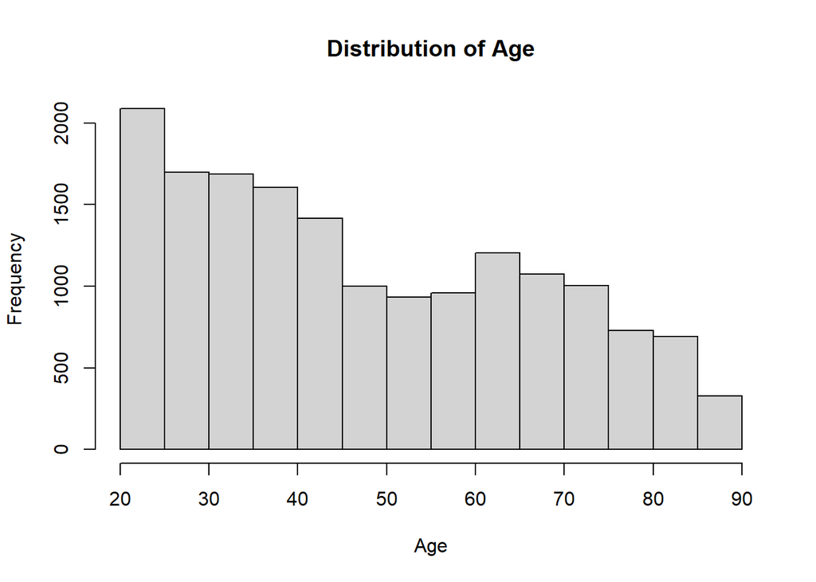

```r
library(tidyverse)
library(dplyr)

data <- read.csv("boneExam_cleaned2.csv", na.strings = c("NA", "NaN"))

# Histogram of Age
hist(data$HSAGEIR, main = "Distribution of Age", xlab = "Age")
```

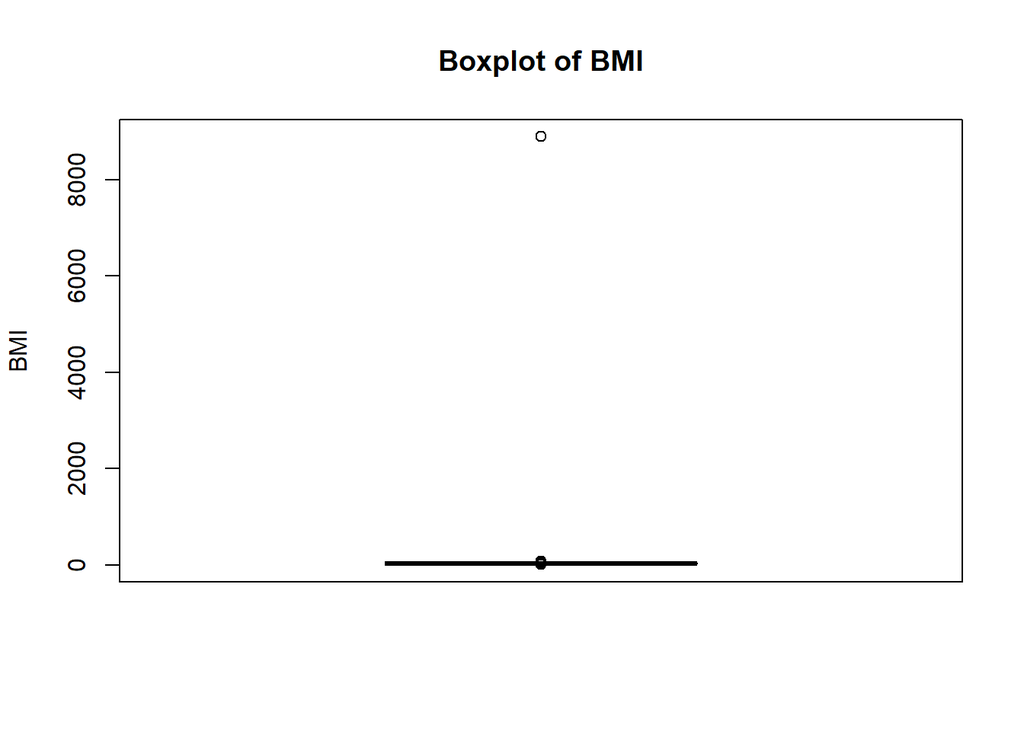

```r
# Boxplot of BMI
boxplot(data$BMPBMI, main = "Boxplot of BMI", ylab = "BMI")
```

# Relationship between BMI and bone health

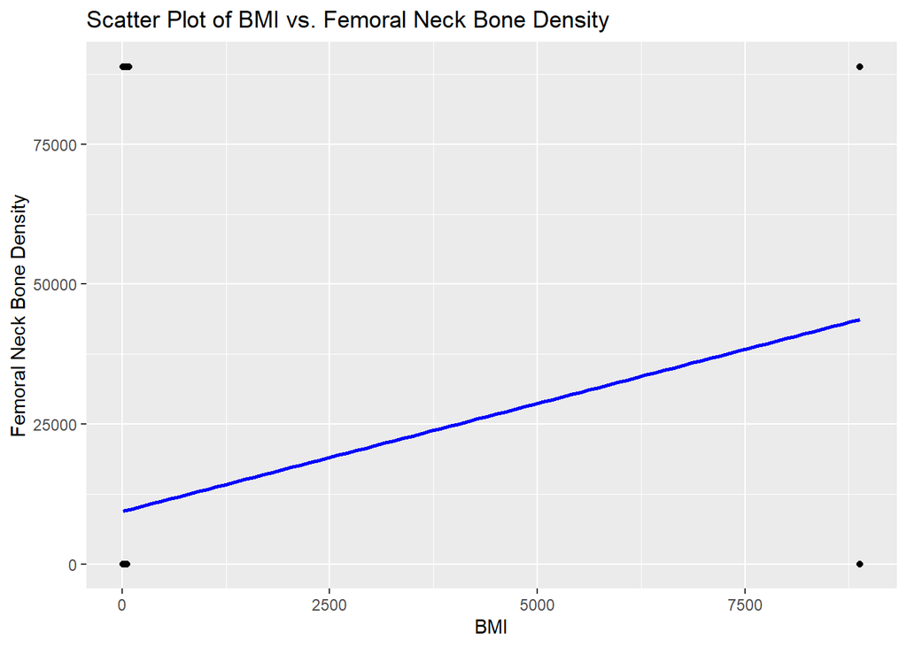

```r
library(tidyverse)
library(dplyr)

cleaned_data <- read.csv("boneExam_cleaned2.csv", na.strings = c("NA", "NaN"))


subset_data <- cleaned_data %>%
  select(BMPWT, BMPBMI, BDPFNBMD)
subset_data <- na.omit(subset_data)


# Scatter plot of BMI vs. Bone Density with regression line
ggplot(subset_data, aes(x = BMPBMI, y = BDPFNBMD)) +
  geom_point() +
  geom_smooth(method = "lm", se = FALSE, color = "blue") +
  labs(title = "Scatter Plot of BMI vs. Femoral Neck Bone Density",
       x = "BMI",
       y = "Femoral Neck Bone Density")
```

```r
# Correlation
correlation <- cor(subset_data$BMPBMI, subset_data$BDPFNBMD)
model <- lm(BDPFNBMD ~ BMPBMI, data = subset_data)
cat("Correlation between BMI and Femoral Neck Bone Density:", correlation, "\n\n")
```

```
## Correlation between BMI and Femoral Neck Bone Density: 0.06775302
```

```r
summary(model)
```

```
##
## Call:
## lm(formula = BDPFNBMD ~ BMPBMI, data = subset_data)
##
## Residuals:
##    Min     1Q Median     3Q    Max
## -43719  -9491  -9476  -9461  79459
##
## Coefficients:
##              Estimate Std. Error t value Pr(>|t|)
## (Intercept) 9377.7910   216.0042   43.41   <2e-16 ***
## BMPBMI         3.8639     0.4441    8.70   <2e-16 ***
## ---
## Signif. codes:  0 '***' 0.001 '**' 0.01 '*' 0.05 '.' 0.1 ' ' 1
##
## Residual standard error: 27510 on 16414 degrees of freedom
## Multiple R-squared:  0.00459,    Adjusted R-squared:  0.00453
## F-statistic:  75.7 on 1 and 16414 DF,  p-value: < 2.2e-16
```

Linear Regression Analysis:

The linear regression model is given by: Femoral Neck Bone Density=9377.79+3.86×BMPBMI

Interpretation of Coefficients: Intercept (9377.79): The estimated baseline femoral neck bone density when BMI is zero. However, this value might not have a meaningful interpretation in the context of BMI and bone density. BMPBMI (3.86): The estimated change in femoral neck bone density for a one-unit increase in BMI. The coefficient is statistically significant (p<0.05), indicating that there is evidence of a relationship. Residuals: Residuals represent the differences between the observed and predicted values of femoral neck bone density. The residual standard error is 27510, indicating the typical magnitude of these differences. Model Fit: R-squared: 0.00459 Only about 0.46% of the variability in femoral neck bone density is explained by the model. F-statistic: 75.7 with a very low p-value The model is statistically significant, suggesting that at least one predictor variable (BMI) is related to femoral neck bone density.

The correlation coefficient between BMI (Body Mass Index) and Femoral Neck Bone Density is approximately 0.06775. This positive correlation coefficient suggests a weak positive linear relationship between BMI and Femoral Neck Bone Density in the NHANES III dataset. The correlation is positive, indicating that as BMI increases, there is a tendency for Femoral Neck Bone Density to increase slightly. However, the strength of this relationship is relatively weak. It’s important to note that correlation does not imply causation, and other factors may influence bone density.

# Relationship between Age and bone health

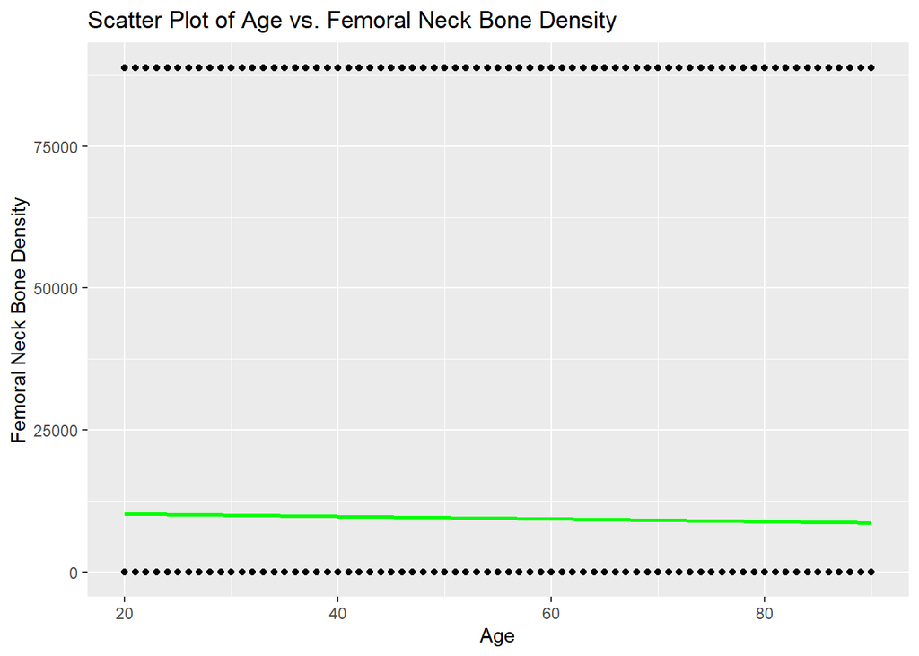

```r
library(tidyverse)
library(dplyr)

cleaned_data <- read.csv("boneExam_cleaned2.csv", na.strings = c("NA", "NaN"))


subset_data <- cleaned_data %>%
  select(HSAGEIR, BDPFNBMD)
subset_data <- na.omit(subset_data)

# Scatter plot of Age vs. Bone Density with regression line
ggplot(subset_data, aes(x = HSAGEIR, y = BDPFNBMD)) +
  geom_point() +
  geom_smooth(method = "lm", se = FALSE, color = "green") +
  labs(title = "Scatter Plot of Age vs. Femoral Neck Bone Density",
       x = "Age",
       y = "Femoral Neck Bone Density")
```

```r
# Correlation
age_correlation <- cor(subset_data$HSAGEIR, subset_data$BDPFNBMD)
age_model <- lm(BDPFNBMD ~ HSAGEIR, data = subset_data)
cat("Correlation between Age and Femoral Neck Bone Density:", age_correlation, "\n\n")
```

```
## Correlation between Age and Femoral Neck Bone Density: -0.01564076
```

```r
summary(age_model)
```

```
##
## Call:
## lm(formula = BDPFNBMD ~ HSAGEIR, data = subset_data)
##
## Residuals:
##    Min     1Q Median     3Q    Max
## -10213  -9922  -9564  -9072  80240
##
## Coefficients:
##             Estimate Std. Error t value Pr(>|t|)
## (Intercept) 10660.72     578.37  18.432   <2e-16 ***
## HSAGEIR       -22.37      11.16  -2.004   0.0451 *
## ---
## Signif. codes:  0 '***' 0.001 '**' 0.01 '*' 0.05 '.' 0.1 ' ' 1
##
## Residual standard error: 27570 on 16414 degrees of freedom
## Multiple R-squared:  0.0002446,  Adjusted R-squared:  0.0001837
## F-statistic: 4.016 on 1 and 16414 DF,  p-value: 0.04508
```

Linear Regression Analysis:

The linear regression model is given by: Femoral Neck Bone Density=10660.72−22.37×Age

Interpretation of Coefficients: Intercept (10660.72): Represents the estimated baseline femoral neck bone density when age is zero. However, this value might not have a practical interpretation in the context of age and bone density. Age (-22.37): Represents the estimated change in femoral neck bone density for a one-unit increase in age. The negative coefficient is consistent with the negative correlation. However, the coefficient is relatively small and marginally significant (p=0.0451). Residuals: Residuals represent the differences between the observed and predicted values of femoral neck bone density. Model Fit: R-squared: The proportion of the variability in femoral neck bone density explained by the model is extremely low (0.0002446), consistent with the weak correlation and small coefficient for Age. F-statistic: 4.016 The model is marginally statistically significant, suggesting that age may have a weak association with femoral neck bone density.

The correlation between Age and Femoral Neck Bone Density is approximately -0.01564. This correlation coefficient suggests a very weak negative linear relationship between age and femoral neck bone density in the NHANES III dataset. The negative sign indicates that, on average, as age increases, there is a slight tendency for femoral neck bone density to decrease, although the correlation is minimal.

# Relationship between Ethnicity and bone health

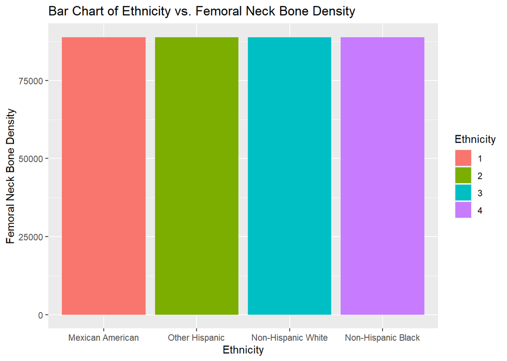

```r
library(dplyr)


cleaned_data <- read.csv("boneExam_cleaned2.csv", na.strings = c("NA", "NaN"))

subset_data <- cleaned_data %>%
  select(DMARETHN, BDPFNBMD)
subset_data <- na.omit(subset_data)

# Bar chart of Ethnicity vs. Bone Density
ggplot(subset_data, aes(x = factor(DMARETHN), y = BDPFNBMD, fill = factor(DMARETHN))) +
  geom_bar(stat = "identity", position = "dodge") +
  labs(title = "Bar Chart of Ethnicity vs. Femoral Neck Bone Density",
       x = "Ethnicity",
       y = "Femoral Neck Bone Density") +
  scale_x_discrete(labels = c("Mexican American", "Other Hispanic", "Non-Hispanic White", "Non-Hispanic Black", "Other")) +
  scale_fill_discrete(name = "Ethnicity")
```

```r
plot_data <- subset_data[, c("DMARETHN", "BDPFNBMD")]
summary_stats <- plot_data %>%
  group_by(DMARETHN) %>%
  summarise(mean_bone_density = mean(BDPFNBMD),
            median_bone_density = median(BDPFNBMD),
            sd_bone_density = sd(BDPFNBMD))
print(summary_stats)
```

```
## # A tibble: 4 × 4
##   DMARETHN mean_bone_density median_bone_density sd_bone_density
##      <int>             <dbl>               <dbl>           <dbl>
## 1        1             7215.               0.78           24276.
## 2        2            11206.               0.938          29506.
## 3        3            11600.               0.885          29945.
## 4        4             8876.               0.823          26668.
```

There are variations in the mean Femoral Neck Bone Density across different ethnicities. The highest mean is observed in Non-Hispanic White individuals, followed by Other Hispanic, Non-Hispanic Black, and Mexican American individuals.The median Femoral Neck Bone Density also shows variations among ethnicities. Other Hispanic individuals have the highest median, while Mexican American individuals have the lowest.Non-Hispanic White individuals tend to have higher mean bone density, while Other Hispanic individuals have the highest median. Variability in bone density is also observed, with higher standard deviations indicating a wider range of values within Non-Hispanic White and Other Hispanic groups.